# R Notebook

Clear packages

```r
lapply(paste('package:',names(sessionInfo()$otherPkgs),sep=""),detach,character.only=TRUE,unload=TRUE)
```

Load packages

```r
library(data.table)
library(dplyr)
library(factoextra)
library(ggplot2)
library(gplots)
library(pheatmap)
library(RColorBrewer)
library(colorspace)
library(dendextend)
library(Rmisc)
```

Load original TPM data (for labels) and pheno data

```r
TPM <- fread("Output/HPAblood_109_TPMexpression.csv")
pheno <- fread("Output/HPAblood_109_pheno_withType.csv", colClasses=c("character"))
identical(colnames(TPM)[-1], pheno$Sample_ID)
```

```
[1] FALSE
```

```r
pheno <- pheno[match(colnames(TPM)[-1], pheno$Sample_ID) ,]
identical(colnames(TPM)[-1], pheno$Sample_ID)
```

```
[1] TRUE
```

Load Cellfie results

```r
res.cellfie <- fread("CellFie_output/blood/metabolism_secretion/minmaxmean/109_pTPM/score.csv") %>%
  setNames(colnames(TPM)[-1])
res.cellfie.binary <- fread("CellFie_output/blood/metabolism_secretion/minmaxmean/109_pTPM/score_binary.csv") %>%
  setNames(colnames(TPM)[-1])
taskInfo <- fread("CellFie_output/blood/metabolism_secretion/minmaxmean/109_pTPM/taskInfo.csv") %>%
  mutate(Pathway = case_when(stringr::str_detect(taskInfos1, "sec_") ~ 'Secretory',
         !stringr::str_detect(taskInfos1, "sec_") ~ 'Metabolism')) %>%
  setNames(c("taskID", "Task", "System", "Subsystem", "Pathway"))
res.cellfie.filter <- res.cellfie * res.cellfie.binary
```

TPM matrix

```r
### prepare expression data
TPM.matrix <- as.matrix(TPM[, -1]) %>% `rownames<-`(TPM$ENTREZID) %>% `colnames<-`(pheno$Sample_ID)
# remove constant/zero columns
TPM.matrix <- TPM.matrix[matrixStats::rowSds(TPM.matrix) > 0.001 ,]
```

CellFie matrix

```r
### prepare expression data
cellfie.matrix <- as.matrix(res.cellfie) %>% `rownames<-`(taskInfo$Task) %>% `colnames<-`(pheno$Sample_ID)
# remove constant/zero columns
cellfie.matrix <- cellfie.matrix[matrixStats::rowSds(cellfie.matrix) != 0 ,]
```

Hierarchical Clustering ####################################################################

It is very difficult to get 18 distinct colors Manually attempt to get most distinct colors as possible

```r
library(randomcoloR)
palette <- distinctColorPalette(18)
#pie(rep(1, 18), col=palette)
ann_colors <- list(cell=c(basophil="#E3589A", `classical monocyte`="#DA4FDF", eosinophil="#D86049", `gdT-cell`="#764ADF", `intermediate monocyte`="#7AE94E", `MAIT T-cell`="#D3BEDC", `memory B-cell`="#7FBFDC", `memory CD4 T-cell`="#D291E2", `memory CD8 T-cell`="#7E5C99", `myeloid DC`="#E0989B", `naive B-cell`="#C4E090", `naive CD4 T-cell`="#DEAF66",
`naive CD8 T-cell`="#D8DF52", neutrophil="#DDE0CC", `NK-cell`="#7DE0D1", `non-classical monocyte`="#809173", `plasmacytoid DC`="#6CDE90", `T-reg`="#6E95DE"))
```

Using all cellfie (met+sec)

```r
## no subtype annotations
cellType.col <- list(cellType=brewer.pal(length(unique(pheno$Cell_Type)), "Set2") %>%
  setNames(unique(pheno$Cell_Type)))
set.seed(18)
p.sec <- pheatmap::pheatmap(cellfie.matrix,
                    fontsize=6,
                    main="secCellFie",
                    scale="row",
                    border_color = NA,
                    color=colorRampPalette(c("navy", "white", "red"))(50),
                    clustering_distance_cols = "correlation",
                    clustering_method = "complete",
                    annotation_col = data.frame(cellType=pheno$Cell_Type) %>% `rownames<-`(pheno$Sample_ID),
                    annotation_colors = cellType.col,
                    show_colnames = F,
                    show_rownames = F,
                    treeheight_row = 0,
                    legend_breaks = c(0,1))
```

```r
## with subtype annotations
set.seed(18)
p.sec2 <- pheatmap::pheatmap(cellfie.matrix,
                    fontsize=6,
                    main="secCellFie",
                    scale="row",
                    border_color = NA,
                    color=colorRampPalette(c("navy", "white", "red"))(50),
                    clustering_distance_cols = "correlation",
                    clustering_method = "complete",
                    annotation_col = data.frame(cell=factor(pheno$Immune_Cell), cellType=pheno$Cell_Type) %>% `rownames<-`(pheno$Sample_ID),
                    annotation_colors = append(ann_colors, cellType.col),
                    show_colnames = F,
                    show_rownames = F,
                    treeheight_row = 0,
                    legend_breaks = c(0,1))
```

```r
## DC only subtype annotations
set.seed(18)
p.sec3 <- pheatmap::pheatmap(cellfie.matrix,
                    fontsize=6,
                    main="secCellFie",
                    scale="row",
                    border_color = NA,
                    color=colorRampPalette(c("navy", "white", "red"))(50),
                    clustering_distance_cols = "correlation",
                    clustering_method = "complete",
                    annotation_col = data.frame(cell=factor(pheno$Immune_Cell), cellType=pheno$Cell_Type) %>% `rownames<-`(pheno$Sample_ID) %>% mutate(cell=case_when(cell=='plasmacytoid DC' ~ 'plasmacytoid DC',
                                                                                                                                                                      cell=='myeloid DC' ~ 'myeloid DC',
                                                                                                                                                                      TRUE ~ NA)),
                    annotation_colors = append(cellType.col, list(cell=c(`myeloid DC`="#E0989B",`plasmacytoid DC`="#6CDE90"))),
                    show_colnames = F,
                    show_rownames = F,
                    treeheight_row = 0,
                    legend=F,
                    annotation_legend = F)
```

Using met cellfie only

```r
met.taskInfo <- filter(taskInfo, Pathway=="Metabolism")
## no subtype annotations
p.met <- pheatmap::pheatmap(cellfie.matrix[rownames(cellfie.matrix) %in% met.taskInfo$Task ,],
                    fontsize=6,
                    main="CellFie",
                    scale="row",
                    border_color = NA,
                    color=colorRampPalette(c("navy", "white", "red"))(50),
                    #cluster.cols = hclust(dist(cellfie.matrix, method="euclidean"), method="complete"),
                    clustering_distance_cols = "correlation",
                    clustering_method = "complete",
                    annotation_col = data.frame(cellType=pheno$Cell_Type) %>% `rownames<-`(pheno$Sample_ID),
                    annotation_colors = cellType.col,
                    show_colnames = F,
                    show_rownames = F,
                    treeheight_row = 0,
                    legend=F,
                    annotation_legend = F)
```

```r
## with subtype annotations
set.seed(18)
p.met2 <- pheatmap::pheatmap(cellfie.matrix[rownames(cellfie.matrix) %in% met.taskInfo$Task ,],
                    fontsize=6,
                    main="CellFie",
                    scale="row",
                    border_color = NA,
                    color=colorRampPalette(c("navy", "white", "red"))(50),
                    clustering_distance_cols = "correlation",
                    clustering_method = "complete",
                    annotation_col = data.frame(cell=factor(pheno$Immune_Cell), cellType=pheno$Cell_Type) %>% `rownames<-`(pheno$Sample_ID),
                    annotation_colors = append(ann_colors, cellType.col),
                    show_colnames = F,
                    show_rownames = F,
                    treeheight_row = 0,
                    legend_breaks = c(0,1))
```

```r
## DC only subtype annotations
set.seed(18)
p.met3 <- pheatmap::pheatmap(cellfie.matrix[rownames(cellfie.matrix) %in% met.taskInfo$Task ,],
                    fontsize=6,
                    main="CellFie",
                    scale="row",
                    border_color = NA,
                    color=colorRampPalette(c("navy", "white", "red"))(50),
                    clustering_distance_cols = "correlation",
                    clustering_method = "complete",
                    annotation_col = data.frame(cell=factor(pheno$Immune_Cell), cellType=pheno$Cell_Type) %>% `rownames<-`(pheno$Sample_ID) %>% mutate(cell=case_when(cell=='plasmacytoid DC' ~ 'plasmacytoid DC',
                                                                                                                                                                      cell=='myeloid DC' ~ 'myeloid DC',
                                                                                                                                                                      TRUE ~ NA)),
                    annotation_colors = append(cellType.col, list(cell=c(`myeloid DC`="#E0989B",`plasmacytoid DC`="#6CDE90"))),
                    show_colnames = F,
                    show_rownames = F,
                    treeheight_row = 0)
```

need to use grid.draw function with pheatmaps function to save pheatmap images

```r
save_pheatmap_png <- function(x, filename, width, height, res) {
  png(filename, width = width, height = height, res = res)
  grid::grid.newpage()
  grid::grid.draw(x$gtable)
  dev.off()
}
```

```r
# plot with no legends to get equal size dendrogram
save_pheatmap_png(p.sec3, "Figures/hclust_CellFie_sec3.png", width=1000, height=800, res=350)
```

```r
save_pheatmap_png(p.met, "Figures/hclust_CellFie_met.png", width=1000, height=800, res=350)
```

```r
# plot with legend
save_pheatmap_png(p.met3, "Figures/hclust_CellFie_met3.png", width=1200, height=800, res=300)
```

Compare dendrograms

```r
### dendrogram matching known lineage with manually generated distance matrix
HPAdist.df <- openxlsx::read.xlsx("Output/HPAblood_109_distMatrix.xlsx", colNames=F)
HPA.dist <- as.matrix(HPAdist.df[-c(1:4), -c(1:4)]) %>%
  apply(2, as.numeric) %>%
  Matrix::forceSymmetric(uplo="L") %>%
  as.matrix() %>%
  `colnames<-`(HPAdist.df$X1[-c(1:4)]) %>%
  `rownames<-`(HPAdist.df$X1[-c(1:4)])
hclust.HPA <- hclust(as.dist(HPA.dist))
#plot(hclust.HPA)
```

tanglegram

```
[1] 0.2756359
```

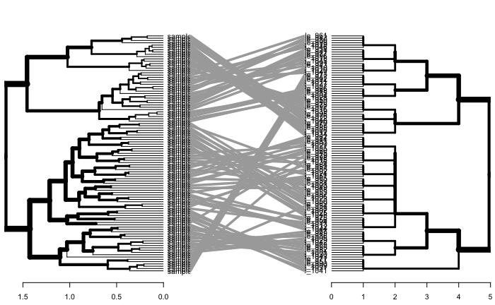

```r
dend.met <- as.dendrogram(p.met$tree_col)
dend.sec <- as.dendrogram(p.sec$tree_col)
dend.HPA <- as.dendrogram(hclust.HPA)
dendList.met <- dendlist(dend.met, dend.HPA)
dendList.sec <- dendlist(dend.sec, dend.HPA)
set.seed(18)
dendList.met %>% #untangle(method="random", R=1) %>%
  untangle(method="DendSer") %>%
  tanglegram(sort=F,
             highlight_distinct_edges = FALSE, # Turn-off dashed lines
             common_subtrees_color_lines = FALSE, # Turn-off line colors
             common_subtrees_color_branches = FALSE # Color common branches
             ) %>% entanglement()
```

```
[1] 0.2920494
```

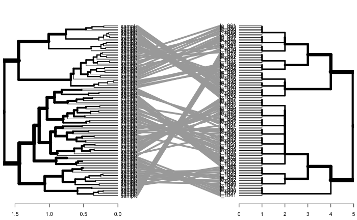

```r
set.seed(18)
dendList.sec %>% #untangle(method="random", R=1) %>%
  untangle(method="DendSer") %>%
  tanglegram(sort=F,
             highlight_distinct_edges = FALSE, # Turn-off dashed lines
             common_subtrees_color_lines = FALSE, # Turn-off line colors
             common_subtrees_color_branches = FALSE # Color common branches
             ) %>% entanglement()
```

correlations

```r
cor.dendlist(dendList.met, method="cophenetic")
```

```
          [,1]      [,2]
[1,] 1.0000000 0.8173441
[2,] 0.8173441 1.0000000
```

```r
cor.dendlist(dendList.met, method="baker")
```

```
          [,1]      [,2]
[1,] 1.0000000 0.8121498
[2,] 0.8121498 1.0000000
```

```r
cor.dendlist(dendList.sec, method="cophenetic")
```

```
         [,1]     [,2]
[1,] 1.000000 0.818445
[2,] 0.818445 1.000000
```

```r
cor.dendlist(dendList.sec, method="baker")
```

```
          [,1]      [,2]
[1,] 1.0000000 0.8173253
[2,] 0.8173253 1.0000000
```

```r
dendList <- dendlist(`CellFie`=dend.met, `secCellFie`=dend.sec, HPA=dend.HPA)
cor.dend <- cor.dendlist(dendList, method="FM_index", k=6)
round(cor.dend, 2)
```

```
           CellFie secCellFie  HPA
CellFie       1.00       0.76 0.70
secCellFie    0.76       1.00 0.59
HPA           0.70       0.59 1.00
```

```r
png("Figures/dend_corr.png", width=600, height=400)
corrplot::corrplot(cor.dend, method="circle", addCoef.col = 'white', col=corrplot::COL1('YlOrBr', 100), type='upper', tl.col = "black", tl.cex=1.5, cl.cex=1.5, cl.align.text = "l", number.cex=1.5, tl.srt=45)
dev.off()
```

Follow up (DENDRITIC only) Isolate DC samples and perform clustering on tasks

```r
nclust <- 2
dendritic <- cellfie.matrix[, pheno$Sample_ID[pheno$Cell_Type=="Dendritic Cells"]]
dendritic <- dendritic[matrixStats::rowSds(dendritic) > 0.0001 ,]

# hierarchcial clustering object that will be used to annotate clusters of plot used for publication
set.seed(18)
hclust.dendritic <- pheatmap::pheatmap(dendritic,
                    fontsize=8, #20
                    main="Hierarchical clustering using secretory expansion of CellFie",
                    scale="row",
                    border_color = NA,
                    color=colorRampPalette(c("navy", "white", "red"))(50),
                    #cluster.cols = hclust(dist(cellfie.matrix, method="euclidean"), method="complete"),
                    clustering_distance_cols = "correlation",
                    clustering_method = "complete",
                    annotation_col = data.frame(cell=factor(pheno$Immune_Cell), cellType=pheno$Cell_Type) %>% `rownames<-`(pheno$Sample_ID),
                    #annotation_row = data.frame( cluster=cutree(hclust.cellfie_clust$tree_row, k=nclust)) %>%
                      #`rownames<-`(rownames(cellfie.matrix)),
                    #annotation_colors = ann_colors,
                    show_colnames = F,
                    show_rownames = F,
                    #treeheight_row = 0,
                    cutree_rows=nclust)
```

```r
save_pheatmap_png(hclust.dendritic.clust, "Figures/hclust_DC.png", width=700, height=900, res=80)
```

Plot cluster trends

```r
task_cluster <- dplyr::select(clust.dendritic, c("cluster", "Task")) %>%
  inner_join(data.frame(Task=rownames(dendritic), t(scale(t(dendritic))))) #%>% setcolorder(c("gene", "cluster", rownames(scale.data)[hmap$colInd]))
#convert wide to long
task_cluster.long <- tidyr::gather(task_cluster, sample, score, sample_1004:sample_992, factor_key=F)
### Too noisy to plot every task. Summarize trend with mean.
task_cluster.summary <- plyr::ddply(task_cluster.long, c("cluster", "sample"), summarise,
                              mean=CI(score, ci=0.95)['mean'],
                              sd=sd(score),
                              se=plotrix::std.error(score),
                              uci=CI(score, ci=0.95)['upper'],
                              lci=CI(score, ci=0.95)['lower'])
cluster.1 <- task_cluster.summary[task_cluster.summary$cluster=="cluster1" ,] %>%
  arrange(match(sample, hclust.dendritic.clust$tree_col$labels[hclust.dendritic.clust$tree_col$order]))
cluster.2 <- task_cluster.summary[task_cluster.summary$cluster=="cluster2" ,] %>%
  arrange(match(sample, hclust.dendritic.clust$tree_col$labels[hclust.dendritic.clust$tree_col$order]))
```

Plot boxplot of cluster trends

```r
box.cluster <- left_join(task_cluster.long,
                          select(pheno, c("Sample_ID", "Immune_Cell")), by=c("sample"="Sample_ID"))
png("Figures/DCcluster_boxplots.png", width = 800, height = 350, res=150)
ggplot(box.cluster, aes(x=Immune_Cell, y=score, fill=Immune_Cell)) +
  geom_boxplot() +
  scale_fill_manual(values = c("#E0989B", "#6CDE90")) +
  theme(axis.ticks.x = element_blank()) +
  facet_wrap(~cluster, scale="free")
dev.off()
```

Tasks in dendritic clusters

```r
dendritic.clusters <- clust.dendritic.sort %>% left_join(taskInfo)
openxlsx::write.xlsx(dendritic.clusters, "Output/DC_clusters.xlsx")
#fwrite(filter(dendritic.clusters, Pathway=="Metabolism"), "Output/DC_Metabolism.csv")
```

Hypergeometric enrichment of cellfie systems in each cluster

```r
set.seed(18)
enrich.1 <- clusterProfiler::enricher(clust.dendritic.sort$Task[clust.dendritic.sort$clusterID==1],
                                      TERM2GENE=dplyr::select(taskInfo, c("Pathway", "Task")),
                                      universe=clust.dendritic.sort$Task,
                                      minGSSize=3,
                                      #maxGSSize=16,
                                      pAdjustMethod = "fdr",
                                      qvalueCutoff = 0.02)
set.seed(18)
enrich.2 <- clusterProfiler::enricher(clust.dendritic.sort$Task[clust.dendritic.sort$clusterID==2],
                                      TERM2GENE=dplyr::select(taskInfo, c("Pathway", "Task")),
                                      universe=clust.dendritic.sort$Task,
                                      minGSSize=3,
                                      #maxGSSize=16,
                                      pAdjustMethod = "fdr",
                                      qvalueCutoff = 0.2)
#enrich_cor.Stress.sig <- enrich_cor.Stress@result %>% subset(p.adjust <= 0.1)
#rm(enrich_cor.Stress)
View(as.data.frame(enrich.1@result)%>% subset(p.adjust <= 0.1))
View(as.data.frame(enrich.2@result)%>% subset(p.adjust <= 0.1))
```

```r
clust.1 <- filter(clust.dendritic.sort, clusterID==1)
clust.2 <- filter(clust.dendritic.sort, clusterID==2)
clust.percent.table <- table(clust.1$System) %>% as.data.frame() %>% `colnames<-`(c("System", "Cluster_1")) %>%
  full_join(table(clust.2$System) %>% as.data.frame() %>% `colnames<-`(c("System", "Cluster_2"))) %>%
  full_join(table(clust.dendritic.sort$System) %>% as.data.frame() %>% `colnames<-`(c("System", "Total"))) %>%
  tidyr::replace_na(list(Cluster_1 = 0, Cluster_2 = 0)) %>%
  left_join(select(taskInfo, c("System", "Pathway")) %>% unique()) %>%
  arrange(Pathway)
```

Differential task activity

```r
welch.tasks <- function(cellfie.score, group1, group2, alt) {
  cellfie.score <- log2(cellfie.score+ 0.00001)
  group1.score <- cellfie.score[names(cellfie.score) %in% group1]
  group2.score <- cellfie.score[names(cellfie.score) %in% group2]
  welch.test <- t.test(group1.score, group2.score, alternative=alt)
  welch.res <- data.frame(p.value=welch.test$p.value, x.mean=welch.test$estimate[1], y.mean=welch.test$estimate[2])
  return(welch.res)
}
```

```r
DE_DC <- apply(dendritic, 1, welch.tasks,
                        group1=pheno$Sample_ID[pheno$Immune_Cell=="myeloid DC"],
                        group2=pheno$Sample_ID[pheno$Immune_Cell=="plasmacytoid DC"],
                        alt="two.sided") %>%
  rbindlist(idcol = "Task") %>% dplyr::rename(myeloid.mean=x.mean) %>% dplyr::rename(plasmacytoid.mean=y.mean) %>% mutate(LFC=(myeloid.mean-plasmacytoid.mean)) %>%
  mutate(FDR=p.adjust(p.value, method="BH")) %>%
  left_join(taskInfo) %>%
  arrange(-LFC)
DE_DC.sig <- DE_DC[FDR <= 0.1 & abs(LFC) >= log2(1.25)]
```

Volcano plot

```r
keyvals.colour <- case_when(
  DE_DC$Task %in% DE_DC.sig$Task[DE_DC.sig$Pathway=="Secretory"] ~ "#008B45",
  DE_DC$Task %in% DE_DC.sig$Task[DE_DC.sig$Pathway=="Metabolism"] ~ "#8B008B",
      .default="black")
names(keyvals.colour)[keyvals.colour == "#008B45"] <- 'Secretory Tasks'
names(keyvals.colour)[keyvals.colour == "#8B008B"] <- 'Metabolic Tasks'
names(keyvals.colour)[keyvals.colour == 'black'] <- 'Non-signficant'
png("Figures/volcano_HPA.png", width=1000, height=600)
EnhancedVolcano::EnhancedVolcano(DE_DC,
                                 lab=DE_DC$Task,
                                 colCustom = keyvals.colour,
                                 x= "LFC",
                                 y="FDR",
                                 axisLabSize = 24,
                                 pCutoff=0.1,
                                 FCcutoff = log2(1.25),
                                 labSize = 0,
                                 title = "Dendritic Cell Volano Plot",
                                 titleLabSize = 30,
                                 subtitle = bquote(italic('myeloid DCs vs. plasmacytoid DCs')),
                                 subtitleLabSize = 24,
                                 ylim=c(0,5),
                                xlim=c(-8.5, 8.5),
                                pointSize = 4,
                                 caption = bquote(~Log[2]~ "fold change cutoff: 1.25; FDR cutoff: 0.1"),
                                 captionLabSize = 20,
                                 legendPosition = "right",
                                 legendLabels = c("NS", ~Log[2]~"FC", "FDR", ~Log[2]~"FC and FDR"),
                                 legendLabSize = 24,
                                 colAlpha = 0.9,
                                 ylab = expression("-Log"[10]*" FDR")
                                 ) #+ theme_classic()
dev.off()
```